# Chapitre 10

## Le futur se trace

Manœuvrer dans le digital avec les cartes de Wardley

Le futur se trace

Manœuvrer dans le digital avec les cartes de Wardley

Olivier Wulveryck

# Chapitre 10 : Jouer sur la carte — Les schémas stratégiques

## Du diagnostic à l’intervention

Un médecin qui ne sait que diagnostiquer est incomplet. Vient le moment d’intervenir : *jouer* sur la carte, non pas subir les mouvements mais les provoquer, les accélérer, les ralentir selon nos intérêts stratégiques.

Simon Wardley a catalogué plus de soixante manœuvres distinctes[^1], qu’il appelle collectivement le **Gameplay** (que nous traduirons ici par **manœuvres stratégiques**). Ce répertoire peut sembler intimidant. Notre objectif n’est pas de les mémoriser toutes, mais de comprendre leur logique profonde et de maîtriser celles qui comptent le plus dans l’économie numérique contemporaine.

## La grammaire de l’action : Climat, Doctrine, Manœuvre

### Ce qui est subi : Le Climat

Le Climat représente les forces que vous ne contrôlez pas. Ce sont les règles du jeu qui s’imposent à tous les acteurs, indépendamment de leur volonté ou de leur puissance.

L’évolution vers la commodité est une force climatique. Vous pouvez la ralentir temporairement, mais vous ne pouvez pas l’arrêter. Les effets de réseau sont climatiques. L’offre et la demande sont climatiques. L’inertie des clients face au changement est climatique.

Lutter contre le climat est une dépense d’énergie futile. C’est comme protester contre la gravité : vous pouvez sauter, mais vous retomberez. L’erreur stratégique la plus coûteuse consiste à investir massivement pour empêcher une technologie de devenir une commodité. Vous gagnez peut-être du temps, mais vous perdez la guerre.

Le stratège avisé ne combat pas le climat. Il l’utilise. Il positionne ses pions pour que les forces naturelles jouent en sa faveur.

### Ce qui est universel : La Doctrine

La Doctrine, que nous avons explorée en Partie II, rassemble les principes de bonne gestion qui s’appliquent quelle que soit votre stratégie. Ce sont des impératifs absolus, des règles d’hygiène qui ne tolèrent aucune exception contextuelle.

Ne jamais reconstruire une commodité existante. Toujours se concentrer sur les besoins de l’utilisateur. Éliminer les duplications inutiles. Utiliser les méthodes appropriées à chaque phase d’évolution. Ces principes ne dépendent pas de votre position sur la carte ni de la stratégie de vos concurrents. Ils sont vrais universellement.

Une organisation qui viole sa doctrine (qui reconstruit des commodités, qui ignore ses utilisateurs, qui fonctionne en silos) échouera quelle que soit la brillance de ses manœuvres stratégiques. La doctrine est le socle. Sans elle, tout s’effondre.

### Ce qui est choisi : La Manœuvre stratégique

La Manœuvre stratégique, objet de ce chapitre, est radicalement différente. Contrairement au Climat (subi) et à la Doctrine (universelle), la Manœuvre est **intrinsèquement contextuelle**.

**Définition : La Manœuvre stratégique**

La Manœuvre stratégique désigne l’ensemble des actions délibérées qu’une organisation peut choisir d’exécuter pour modifier sa position relative sur la carte. Contrairement à la Doctrine, la Manœuvre n’est ni bonne ni mauvaise dans l’absolu : sa valeur dépend entièrement du contexte (votre position, celle de vos adversaires, les forces climatiques en cours, et votre capacité à exécuter).

Une même manœuvre peut être brillante dans un contexte et suicidaire dans un autre.

Prenons un exemple. La standardisation d’une technologie est une manœuvre puissante si vous cherchez à construire des services à valeur ajoutée par-dessus cette technologie. En commoditisant la couche inférieure, vous réduisez vos coûts et vous libérez des ressources pour innover au-dessus.

Mais cette même standardisation devient désastreuse si cette technologie constitue votre unique source de différenciation. Vous détruisez alors votre propre avantage concurrentiel.

La manœuvre est l’art de choisir la bonne action en fonction de la configuration spécifique de l’échiquier. C’est pourquoi elle ne peut être apprise par des recettes : elle exige la lecture de la carte, la compréhension des forces en présence, et le jugement du stratège.

### Manœuvre ou tactique : Une distinction fondamentale

Avant de plonger dans le répertoire des schémas stratégiques, une clarification terminologique s’impose. En français, **manœuvre** et **tactique** semblent interchangeables. Leur étymologie révèle pourtant une différence profonde. **Manœuvre** vient du latin *manuopera* (le travail de la main) : c’est l’action de déplacer, de changer la configuration des pièces sur l’échiquier. La manœuvre est un **mouvement de positionnement** qui modifie le terrain avant l’engagement, de sorte que la bataille devienne plus facile, voire inutile. **Tactique** vient du grec *tassein* (ordonner, disposer en ordre de bataille) : c’est l’art de l’**engagement direct**, la manière dont vous optimisez l’efficacité du combat une fois engagé.

Wardley insiste sur le fait que les organisations se concentrent trop sur l’exécution (faire mieux ce qu’elles font déjà) et pas assez sur le positionnement (changer les règles du jeu avant de l’engager). Construire un modèle ILC pour capturer l’innovation externe, c’est une **manœuvre** : vous changez la structure du terrain. Optimiser votre système CI/CD pour déployer plus vite, c’est une **tactique** : vous améliorez votre efficience dans l’exécution (ce qui est précieux, mais ne change pas votre position relative sur la carte).

C’est pourquoi Wardley nomme ses schémas *gameplays* : des « coups du jeu » qui redéfinissent les positions. En français, **manœuvre stratégique** est le terme le plus juste. Dans le reste de l’ouvrage, nous utiliserons **manœuvre stratégique** (ou simplement **manœuvre**) pour désigner ce que Wardley appelle *Gameplay*. Le terme **tactique**, quant à lui, fera spécifiquement référence à l’optimisation de l’exécution.

## Les jeux d’écosystème : le modèle ILC

### Devenir l’architecte de l’écosystème

Le modèle ILC (pour *Innovate, Leverage, Commoditize*, soit Innover, Amplifier, Commoditiser) représente l’une des contributions les plus puissantes de Wardley à la stratégie contemporaine. Souvent associé à la montée en puissance d’Amazon Web Services, il décrit comment une organisation peut passer du statut de simple fournisseur à celui d’**architecte d’écosystème**.

**Définition : La Plateforme**

Une plateforme est un modèle d’affaires qui crée de la valeur en facilitant les échanges entre deux ou plusieurs groupes interdépendants (généralement des producteurs et des consommateurs).

Sa caractéristique distinctive est qu’elle ne possède pas nécessairement les moyens de production. Elle orchestre les interactions et capture une partie de la valeur qui transite. Apple ne fabrique pas les applications de l’App Store. Uber ne possède pas les véhicules. Amazon Marketplace ne produit pas les biens vendus.

La puissance d’une plateforme réside dans les **effets de réseau croisés** : plus il y a de producteurs, plus les consommateurs affluent ; plus il y a de consommateurs, plus les producteurs veulent être présents. Ce cercle vertueux crée des barrières à l’entrée considérables une fois la masse critique atteinte.

Le modèle ILC exploite cette dynamique de plateforme en trois phases distinctes.

### Phase 1 : Innover (*Innovate*)

La première phase repose sur un paradoxe apparent : l’entreprise dominante ne cherche pas à monopoliser l’innovation. Au contraire, elle fournit des briques technologiques de base (calcul, stockage, base de données, services d’authentification) sous forme d’API (*Application Programming Interface*, interface de programmation applicative) à bas coût.

Elle invite ensuite un écosystème externe (développeurs indépendants, startups, partenaires) à bâtir des applications par-dessus ces briques. En agissant ainsi, elle **externalise le risque**. La grande majorité de ces nouvelles applications échoueront. C’est la nature même de l’innovation en phase de Genèse : une idée sur mille réussit[^2]. Mais cet échec est supporté par l’écosystème, non par la plateforme.

Pensez à AWS dans les années 2010. Amazon fournissait l’infrastructure. Des milliers de startups construisaient des applications dessus. Certaines ont échoué. D’autres ont prospéré. Amazon ne prenait aucun risque sur le succès individuel de ces expériences. Elle se contentait de facturer les ressources consommées.

### Phase 2 : Amplifier (*Leverage*)

La deuxième phase est celle de l’asymétrie d’information. En tant que fournisseur de l’infrastructure sous-jacente, la plateforme possède une vue omnisciente sur les données de consommation.

Elle observe le volume de données stockées par chaque application. Elle mesure la fréquence des appels API. Elle détecte les patterns d’usage qui émergent. Elle devient ce que Wardley appelle un **Moteur de Détection** (*Sensing Engine*), un radar capable d’identifier les signaux faibles de succès bien avant le reste du marché.

L’entreprise n’a pas besoin de deviner ce qui sera le prochain grand succès. Elle le regarde émerger en temps réel sur ses propres serveurs. Quand une application tierce commence à consommer massivement des ressources de base de données, c’est un signal. Quand les appels à une certaine API explosent, c’est un signal. La plateforme voit le futur se dessiner dans ses métriques de facturation.

Cette asymétrie d’information est le véritable levier du modèle. Elle transforme la plateforme en oracle du marché.

### Phase 3 : Commoditiser (*Commoditize*)

La troisième phase conclut le cycle. Une fois qu’une innovation externe a prouvé sa valeur et atteint une certaine maturité (passant de la Genèse au Produit), la plateforme intervient.

Elle ne rachète pas nécessairement la startup innovante. Elle lance sa propre version du service, intégrée nativement dans son offre, plus robuste, bénéficiant d’effets d’échelle massifs qui permettent des prix inférieurs. Elle **commoditise** l’innovation.

Amazon lançant Lambda après avoir observé l’émergence des architectures *serverless* sur ses serveurs. Amazon lançant Comprehend après avoir constaté l’explosion de l’analyse de texte par *machine learning*[^3]. Le cas de DynamoDB est légèrement différent : la technologie est née d’un besoin interne d’Amazon (le passage à l’échelle du panier d’achat, documenté dans le célèbre *Dynamo Paper* de 2007) avant d’être proposée comme service managé en 2012. Mais le résultat est identique : une brique qui devient commodité pour l’écosystème.

Les pionniers initiaux sont soit absorbés, soit marginalisés. Mais la valeur se déplace vers la plateforme, qui s’enrichit d’une nouvelle brique standard. Et cette nouvelle brique devient le socle pour la prochaine vague d’innovation — retour à la Phase 1.

C’est une machine à croissance perpétuelle.

### Implications pour l’architecte

L’analyse du modèle ILC ne doit pas se limiter à une étude de cas d’Amazon. Comment l’appliquer à votre propre contexte ?

**Identifier les composants plateforme.** Dans votre système d’information, quels composants possèdent le potentiel de devenir des services utilitaires pour d’autres ? Une base de données clients particulièrement riche. Un moteur logistique sophistiqué. Un système de paiement robuste. Ces composants peuvent être les fondations d’une stratégie ILC à votre échelle.

**Construire une stratégie API.** Les API ne sont pas de simples interfaces techniques. Ce sont les instruments du *Leverage*. Sans une stratégie API qui permet non seulement l’accès mais aussi la mesure précise de l’usage, le modèle ILC est impossible. La donnée d’usage est le carburant du modèle. Si vous ne mesurez pas ce qui se passe sur votre plateforme, vous êtes aveugle aux opportunités.

**Gérer l’équilibre écosystème.** Le modèle ILC est intrinsèquement prédateur. Si vous commoditisez trop vite les innovations de vos partenaires, vous étranglez l’écosystème et tarissez la source d’innovation. Si vous attendez trop, vous laissez d’autres capturer la valeur. L’art réside dans le timing : nourrir l’écosystème suffisamment longtemps pour qu’il innove, récolter avant que d’autres ne le fassent.

### Cas d’étude européen : Carrefour et la transformation plateforme

L’application du modèle ILC ne se limite pas aux géants technologiques américains. Carrefour, acteur historique de la distribution française, illustre une tentative européenne de transition vers un modèle plateforme face à la menace Amazon[^4].

Au milieu des années 2010, Carrefour fait face à une double menace. Amazon grignote ses parts de marché sur les produits non-alimentaires. Simultanément, des *pure players* alimentaires (Picnic aux Pays-Bas, Rohlik en République tchèque) émergent avec des modèles nativement numériques.

La réponse de Carrefour suit la logique ILC. En Phase 1 (Innover), l’enseigne ouvre progressivement sa marketplace à partir de 2017 au Brésil, puis en France en 2020. Les vendeurs tiers peuvent utiliser l’infrastructure logistique et les surfaces commerciales de Carrefour, via des API de catalogue, stocks, paiement et *click & collect*. En Phase 2 (Amplifier), Carrefour observe quels produits se vendent le mieux via les vendeurs tiers : données de conversion, paniers moyens, taux de retour permettent d’identifier les niches rentables (produits bio locaux, épicerie fine, produits zéro déchet).

C’est en Phase 3 (Commoditiser) que le modèle atteint ses limites. En théorie, les catégories à succès validées par la marketplace devraient être intégrées en marque propre. En pratique, Carrefour n’a pas encore démontré publiquement cette boucle de rétroaction entre données marketplace et développement de ses gammes. L’entreprise possède les ingrédients (données de vente, infrastructure logistique, capacité de marque propre), mais le passage de la Phase 2 à la Phase 3 reste le maillon faible de sa stratégie plateforme.

Contrairement à AWS, Carrefour bute sur des obstacles spécifiques. Le conflit de canaux est réel : les vendeurs tiers craignent d’être cannibalisés après avoir prouvé le marché. La régulation européenne (DMA ou *Digital Markets Act*, RGPD) encadre de plus en plus les pratiques d’utilisation des données vendeurs. Et la culture organisationnelle reste celle d’un distributeur physique, pas d’une plateforme technologique. La marketplace ne représente encore qu’une fraction du chiffre d’affaires e-commerce (contre plus de 50% pour Amazon). Carrefour a réussi à ralentir l’érosion mais n’a pas construit un véritable moteur ILC auto-renforçant.

Le modèle ILC exige une exécution complète des trois phases. Carrefour illustre un ILC inachevé : transposer un modèle technologique dans le retail physique nécessite une transformation culturelle profonde que peu d’acteurs traditionnels réussissent.

## Les accélérateurs : L’Open Source comme arme stratégique

### Dépasser l’idéalisme

Dans l’imaginaire collectif de la technologie, l’Open Source est souvent associé à des valeurs de partage, de collaboration et d’éthique communautaire. C’est une vision respectable, mais incomplète.

Dans la cartographie de Wardley, l’ouverture (Open Source, Open Data, Open Standards) est avant tout une **arme stratégique**. Son effet principal est d’accélérer violemment l’évolution d’un composant vers la commodité. En rendant le code source librement accessible, l’organisation réduit drastiquement les barrières à l’entrée et à l’adoption. Elle permet la duplication, la modification, la diffusion rapide.

Sur une carte, cela se traduit par un déplacement forcé d’un composant de la gauche (Produit, différencié, à forte marge) vers la droite (Commodité, standard, à marge nulle).

La question que le stratège doit se poser est simple : **pourquoi investir des millions pour développer un logiciel que l’on offre ensuite gratuitement ?**

### Commoditiser le complément

La réponse réside dans la théorie des **produits complémentaires**. La demande pour un produit A est souvent corrélée à la demande pour un produit B. Si vous vendez le produit B, vous avez tout intérêt à ce que le produit A soit le moins cher possible, voire gratuit.

En commoditisant A, vous baissez le coût total de possession pour le client et augmentez la demande pour B (votre véritable source de revenus)[^5].

L’exemple d’Android illustre parfaitement ce mécanisme. Google ne tire pas ses revenus de la vente de licences logicielles ni de matériel téléphonique. Ses revenus viennent de la publicité et des services en ligne (Search, YouTube, Maps, Gmail).

Pour sécuriser ces revenus, Google avait besoin que l’accès à Internet via mobile soit omniprésent et bon marché. À l’époque, les systèmes d’exploitation mobiles (Symbian, Windows Mobile, iOS) constituaient des verrous coûteux ou restrictifs.

En lançant Android en Open Source via l’*Open Handset Alliance* en 2007, Google n’a pas fait acte de charité[^6]. Il a **commoditisé la couche OS**. Il a transformé ce qui était un facteur de différenciation critique et une source de revenus pour Nokia ou Microsoft en un bien commun gratuit.

Cette manœuvre a détruit la marge de ses concurrents sur le logiciel, fait baisser le prix des smartphones, explosé le nombre d’utilisateurs connectés, et in fine alimenté le moteur économique de Google.

La valeur n’a pas été détruite. Elle a été **déplacée** — de la couche OS vers la couche Services, là où Google l’attendait.

### Quand jouer l’ouverture

L’Open Source n’est pas une stratégie universelle. C’est une manœuvre, donc contextuelle. Voici les situations où elle est pertinente :

**En attaque.** Si un concurrent tire une rente de situation d’un composant propriétaire coûteux qui freine votre croissance, soutenir ou lancer une alternative Open Source est le moyen le plus efficace de détruire sa marge. C’est une stratégie de « terre brûlée » sur la couche inférieure pour gagner sur la couche supérieure.

**En défense.** Si votre produit phare est menacé par un standard fermé qui risque de vous exclure du marché, l’ouvrir peut permettre de créer une coalition d’alliés autour d’un standard commun dont vous garderez l’influence.

**Pour la standardisation.** En phase de transition Produit-Commodité, ouvrir la technologie est le moyen le plus rapide d’imposer un standard de facto. Vous captez la base installée et vous construisez des services à valeur ajoutée sur ce socle standardisé (modèle Open Core).

Le piège à éviter : ouvrir un composant qui constitue votre unique source de différenciation. Si vous commoditisez votre propre avantage concurrentiel sans contrôler une couche adjacente où capturer la valeur, vous vous suicidez stratégiquement.

## Les freins : Le PID et le Château et Douves

### Le PID : Cultiver l’inertie des autres

Si l’Open Source sert à accélérer le mouvement, le **PID** (pour *Peur, Incertitude, Doute*, de l’anglais *Fear, Uncertainty, Doubt* ou FUD) est son exact opposé : un frein artificiel conçu pour ralentir l’évolution.

Le PID consiste à disséminer stratégiquement des informations (vraies, partiellement vraies, ou délibérément vagues) pour induire la peur du changement chez les clients de vos concurrents.

La **Peur** d’abord : « Cette nouvelle technologie Open Source n’a pas de support entreprise. Qui appellera-t-on à trois heures du matin ? » L’**Incertitude** ensuite : « La feuille de route de cette startup est floue. Leur modèle économique est-il vraiment pérenne ? Seront-ils encore là dans deux ans ? » Le **Doute** enfin : « Est-ce vraiment compatible avec vos systèmes critiques ? Le coût de migration ne risque-t-il pas d’exploser ? »

L’objectif est de gagner du temps (le temps d’adapter sa propre offre avant que le marché ne bascule). C’est une manœuvre défensive qui exploite l’aversion au risque naturelle des organisations.

Sur une carte de Wardley, le PID agit comme une barrière invisible qui tente de bloquer un composant en phase Produit et d’empêcher son glissement naturel vers la Commodité.

L’architecte doit savoir reconnaître quand il est victime de PID (pour rassurer ses parties prenantes internes et ne pas tomber dans le piège). Il doit aussi comprendre que l’usage du PID, s’il est découvert, peut avoir des répercussions désastreuses sur la réputation. C’est une arme à double tranchant.

### Le Château et les Douves : Une défense temporaire

La stratégie « Château et Douves » (*Castle and Moat*) est un classique, popularisé par Warren Buffett dans ses lettres aux actionnaires de Berkshire Hathaway[^7], mais critiqué par Wardley pour sa vision fondamentalement statique.

Le concept est familier. Le **Château** représente le produit ou service différenciant (celui qui génère de fortes marges et constitue le cœur de la proposition de valeur). Les **Douves** sont les barrières artificielles érigées pour empêcher les concurrents d’attaquer le château ou les clients d’en sortir.

Ces douves prennent de multiples formes : technologiques (protocoles propriétaires, formats de données fermés rendant l’interopérabilité difficile), juridiques (portefeuilles de brevets agressifs, contentieux préventifs), ou contractuelles (frais de sortie prohibitifs, engagements de longue durée, clauses d’exclusivité).

La critique wardleyenne est implacable : cette stratégie est **fondamentalement temporaire**. Dans un climat d’évolution perpétuelle, les douves finissent inévitablement par s’assécher ou être contournées.

Les brevets expirent. Les standards ouverts remplacent les protocoles fermés. Les clients frustrés par le verrouillage finissent par chercher activement des alternatives — et ils sont prêts à payer le prix de la migration.

L’histoire des technologies est jonchée de forteresses abandonnées : les mainframes propriétaires d’IBM contournés par l’architecture client-serveur puis le cloud, les formats fermés de Microsoft Office forcés de s’ouvrir face aux standards ouverts et à Google Docs, les protocoles télécom propriétaires de Nortel balayés par le routage IP standardisé (Nortel a fait faillite en 2009)[^8]. Ces forteresses semblaient imprenables. Elles ne l’étaient pas.

Le Château et les Douves n’est pas une stratégie de long terme. C’est une **tactique** de **moisson** (*harvesting*), un moyen de maximiser l’extraction de valeur sur un produit mature pendant que vous préparez le prochain château. S’enfermer dans ses murs sans préparer la forteresse suivante est une condamnation à mort différée.

## Autres manœuvres du répertoire

Le répertoire de Wardley contient d’autres manœuvres essentielles.

### Les marchés à deux facteurs : Devenir le passage obligé

Cette manœuvre consiste à se positionner comme l’intermédiaire indispensable entre deux groupes distincts (fournisseurs d’un côté, consommateurs de l’autre).

L’action consiste à créer une plateforme où la valeur pour chaque groupe dépend de la taille de l’autre groupe. C’est ce que les économistes appellent les **effets de réseau croisés** : plus il y a de vendeurs, plus les acheteurs viennent ; plus il y a d’acheteurs, plus les vendeurs affluent. Le cercle vertueux s’auto-entretient.

Sur une carte de Wardley, cela se visualise par un nœud central connectant de nombreux agents de part et d’autre. Le but stratégique est double : commoditiser la connexion pour en faire un passage obligé (réduire le coût de transaction au minimum), et capturer les données de flux (comprendre mieux que quiconque ce qui circule sur la plateforme).

Les exemples contemporains abondent : les marketplaces (Amazon, Leboncoin), les app stores (Apple, Google Play), les places de marché financières. La position d’intermédiaire, une fois établie, devient extraordinairement difficile à déloger.

Le piège : cette stratégie nécessite d’atteindre une masse critique des deux côtés simultanément. C’est le fameux problème de la poule et de l’œuf. De nombreuses plateformes échouent avant d’avoir atteint ce point de bascule.

### *Embrace and Extend* : Capturer un standard ouvert

Cette stratégie agressive vise à capturer un standard ouvert pour le refermer progressivement. Elle a été pratiquée avec une efficacité redoutable par Microsoft dans les années 1990.

La première phase, « *Embrace* » (embrasser), consiste à adopter publiquement un standard ouvert qui gagne en popularité. L’entreprise se présente comme un citoyen modèle de l’écosystème ouvert. Elle implémente le standard, parfois mieux que ses créateurs originaux.

La deuxième phase, « *Extend* » (étendre), consiste à ajouter des fonctionnalités propriétaires présentées comme des « améliorations » ou des « innovations ». Ces extensions ne fonctionnent que dans l’environnement de l’entreprise. Elles rendent le standard plus attrayant pour les utilisateurs… mais seulement s’ils restent dans l’écosystème propriétaire.

La troisième phase, souvent implicite, est « *Extinguish* » (éteindre). Les utilisateurs deviennent progressivement dépendants des extensions propriétaires. La compatibilité avec le standard ouvert d’origine se dégrade. Le marché se retrouve verrouillé.

L’exemple historique le plus célèbre est le navigateur Internet Explorer et ses « extensions » au HTML standard[^9]. Mais cette stratégie reste d’actualité dans le cloud, les API, et les formats de données.

L’architecte doit savoir reconnaître cette manœuvre quand elle est utilisée contre lui, et évaluer lucidement s’il est lui-même en position de l’employer.

### Le *Land Grab* : Occuper le terrain avant les autres

Quand un nouveau marché émerge (une nouvelle technologie en phase de Genèse, un nouveau besoin utilisateur qui se cristallise), le premier arrivé qui atteint une masse critique peut créer des barrières durables.

Le **Land Grab** (course à l’occupation) consiste à sacrifier la rentabilité à court terme pour conquérir rapidement des parts de marché. La vitesse d’exécution prime sur la perfection du produit. L’objectif est de devenir le standard de facto avant que les concurrents n’aient le temps de réagir.

Cette stratégie est particulièrement pertinente dans les marchés où les effets de réseau sont forts. Le premier à atteindre la masse critique devient très difficile à déloger. C’est pourquoi tant de startups « brûlent du cash » pour acquérir des utilisateurs : elles jouent le *Land Grab*.

Le risque : épuiser ses ressources avant d’avoir atteint le point de bascule. De nombreuses startups ont disparu en courant après un marché qui n’existait pas encore.

### Les signaux trompeurs : La désinformation stratégique

Certaines manœuvres jouent sur la perception plutôt que sur la réalité. La **Signal Distortion** (distorsion du signal) consiste à feindre un intérêt pour une technologie ou un marché sans avenir réel, afin d’y attirer les concurrents.

C’est une fausse piste délibérée. Pendant que l’adversaire investit dans une direction stérile, vous progressez ailleurs. Cette manœuvre exige une excellente connaissance du paysage concurrentiel et une capacité à jouer la comédie de manière convaincante.

Le **Techdrop** est une variante : révéler soudainement une avance technologique significative pour démoraliser la concurrence. En montrant que vous êtes significativement en avance, vous découragez les investissements adverses dans le même domaine. L’effet est d’autant plus puissant que la démonstration est inattendue.

Ces manœuvres soulèvent des questions éthiques. Elles relèvent de la manipulation et peuvent nuire à la confiance dans un écosystème. L’architecte doit les connaître pour s’en protéger, mais doit réfléchir soigneusement avant de les employer.

**Par où commencer ?**

Face à cet arsenal de manœuvres stratégiques, une question se pose : par où commencer ? Faut-il immédiatement tenter de construire un modèle ILC comme AWS, ou existe-t-il une progression logique ?

La réponse dépend de la maturité de votre organisation. Si vous êtes une startup ou une PME qui découvre Wardley Mapping, commencez par les fondations opérationnelles : le **Strangler Fig** pour réduire votre dette technique sans Big Bang, l’**alignement EVT** pour mettre les bonnes personnes au bon endroit, et la **due diligence stratégique** pour évaluer vos acquisitions sans vous faire piéger. Ces trois manœuvres s’apprennent vite, s’appliquent immédiatement, et génèrent des résultats tangibles en quelques mois.

Une fois ces bases maîtrisées, vous pouvez passer aux manœuvres stratégiques : utiliser l’**Open Source pour commoditiser** un concurrent, construire un **Château et Douves** pour protéger temporairement un avantage, ou préserver vos options via l’**abstraction architecturale**. Ces manœuvres demandent plus de coordination, mais restent à la portée d’une scale-up ou d’une entreprise établie.

Enfin, les manœuvres stratégiques avancées (le modèle **ILC**, les **marchés à deux facteurs**, ou l’**Embrace & Extend**) sont réservées aux organisations matures qui ont déjà prouvé leur capacité à exécuter les niveaux précédents. Tenter de construire un écosystème ILC sans maîtriser le Strangler Fig, c’est comme vouloir courir un marathon sans savoir marcher. Les fondations d’abord, l’ambition ensuite.

## Les manœuvres opérationnelles

Les grands schémas stratégiques comme l’ILC ou l’Open Source dessinent les mouvements de marché. Mais le quotidien de l’architecte est fait de décisions opérationnelles concrètes qui déterminent la capacité de l’organisation à suivre ces mouvements.

### Migration et refonte : Le modèle du *Strangler Fig*

Les termes « refonte » et « migration » sont chargés d’anxiété dans les départements IT. Ils évoquent des projets pharaoniques, des budgets dépassés, des risques opérationnels majeurs.

La carte de Wardley permet de rationaliser ces décisions en les plaçant dans un contexte évolutif.

Sur une carte, une application monolithique vieillissante apparaît souvent comme un gros composant en phase Sur-Mesure (*Custom*), alors qu’elle repose sur des sous-composants (authentification, base de données, logging) qui devraient être des commodités. Cette inadéquation est source d’inertie massive.

L’approche du « Big Bang » (tout réécrire d’un coup) est presque toujours vouée à l’échec. Elle ignore la complexité des dépendances et les risques d’interruption de service.

La stratégie recommandée est celle du **Strangler Fig** (le Figuier Étrangleur), une métaphore botanique qui décrit comment un figuier parasite enveloppe progressivement son hôte jusqu’à le remplacer entièrement.

**Étape 1 : Identifier les composants à commoditiser.** L’analyse de la carte permet d’extraire du monolithe tout ce qui existe désormais sous forme de service standard sur le marché. Remplacer un système d’authentification maison par un service SaaS (*Software as a Service*, comme Auth0 ou Okta) est une migration vers la droite de la carte. Cela réduit la dette technique et libère des ressources.

**Étape 2 : Isoler le cœur de valeur.** Il s’agit d’identifier la logique métier unique (le vrai « Custom ») qui confère l’avantage concurrentiel. Les efforts de refactoring doivent se concentrer exclusivement sur cette partie.

**Étape 3 : Remplacer progressivement.** Chaque fonctionnalité du vieux système est remplacée par un nouveau service, jusqu’à ce que l’ancien système puisse être éteint. La carte permet de planifier ce remplacement composant par composant, en visualisant les dépendances pour minimiser les risques.

L’argument auprès de la direction ne doit pas être technique (« le code est propre ») mais stratégique : la réduction de la dette technique augmente la vélocité et réduit le Time to Market.

### Cas industriel : TireCo et la migration du système MES

**Note :** TireCo est un cas fictif inspiré des pratiques réelles de transformation industrielle, notamment celles de Michelin et d’autres fabricants de pneumatiques. Les chiffres sont des estimations réalistes fondées sur les normes du secteur[^10].

Le pattern Strangler Fig ne s’applique pas qu’au logiciel. TireCo, grand fabricant européen de pneumatiques, l’a utilisé pour transformer son système de pilotage de production (MES - Manufacturing Execution System) sans arrêter les usines.

Le MES historique de TireCo (un monolithe développé en interne dans les années 1990) gérait l’ordonnancement, le suivi qualité, la traçabilité et la maintenance préventive d’une soixantaine d’usines à travers le monde. Toute interruption du système signifiait l’arrêt de la production (coût estimé : 50 000 €/heure/usine). L’option « Big Bang » (arrêter une usine pendant trois mois pour tout réécrire) était inenvisageable : risque opérationnel inacceptable, coût d’opportunité massif, impossibilité de valider le nouveau système en conditions réelles avant la bascule.

L’équipe a opté pour un *Strangler Fig* sur cinq ans, en commençant par cartographier les douze sous-systèmes fonctionnels du monolithe. Sur la carte de Wardley, l’ordonnancement relevait du Sur-mesure (logique métier spécifique), la traçabilité du Produit (standardisable), la collecte de données capteurs de la Commodité (IIoT, *Industrial Internet of Things*, standard), et la maintenance préventive du Produit (modèles prédictifs).

La première vague (2018-2019) a remplacé la collecte de données par une plateforme IIoT standard (Siemens MindSphere), réduisant le monolithe de 30% de son code et validant l’approche sur trois usines pilotes. La fréquence de collecte est passée d’une minute à une seconde, le coût de maintenance a chuté de 40%. La deuxième vague (2019-2021) a migré la traçabilité vers un système SaaS conforme aux normes industrielles, à raison de cinq usines par trimestre. Pendant dix-huit mois, les deux systèmes ont tourné en parallèle avec réconciliation quotidienne, ce qui a permis une conformité réglementaire automatique (ISO 9001, IATF 16949) et une réduction de 60% du temps de réponse aux audits. La troisième vague (2021-2023) a refactoré le cœur métier : l’ordonnancement est resté spécifique mais a été réécrit en microservices, concentré sur l’algorithme d’optimisation propriétaire, consommant les API des commodités déjà migrées.

Après cinq ans, le résultat est parlant : zéro interruption de production majeure liée à la migration, un coût total de 40M€ étalés (contre 80M€ estimés pour un Big Bang), un *time-to-market* réduit de dix-huit mois à trois mois, un volume de code propriétaire divisé par cinq, et la capacité d’intégrer de nouvelles usines acquises sans refonte.

Le *Strangler Fig* fonctionne hors logiciel pur. Dans l’industrie, où l’interruption de service coûte très cher, c’est souvent la seule stratégie viable. La clé est de commencer par commoditiser les couches non-différenciantes, puis de concentrer les efforts de refonte sur le cœur de valeur unique.

### Cas retail : FashionFlow et la migration e-commerce

**Note :** FashionFlow est un cas fictif. Nous utilisons le terme générique « plateforme e-commerce SaaS » pour désigner des solutions comme Shopify, PrestaShop Cloud, WooCommerce, ou équivalents (le principe stratégique s’applique indépendamment de l’éditeur spécifique).

Au chapitre 9, nous avons suivi FashionFlow, chaîne de 25 magasins de prêt-à-porter, dans son analyse Flow. La carte avait révélé trois problèmes : un coût caché de l’omnicanalité (108 k€/an pour l’intégration stocks), un site e-commerce sur-mesure alors que des solutions Produit existent, et une dépendance critique à une équipe de deux développeurs.

La décision semblait évidente : migrer vers une plateforme e-commerce SaaS et concentrer l’équipe sur l’intégration différenciante. Mais comment gérer l’**incertitude** inhérente à cette transformation ?

**Les risques identifiés :**

FashionFlow fait face à plusieurs scénarios défavorables possibles. La plateforme SaaS pourrait modifier ses conditions tarifaires une fois la migration effectuée (c’est le risque classique de dépendance à une plateforme). Un concurrent pourrait lancer une offre e-commerce spécialisée retail avec intégration stocks native, rendant l’avantage concurrentiel de FashionFlow moins différenciant. Enfin, la réglementation européenne pourrait imposer des contraintes de localisation des données que la plateforme SaaS ne respecterait pas.

**La stratégie choisie : Strangler Fig + Abstraction**

FashionFlow a combiné plusieurs manœuvres pour préserver ses options.

**Phase 1 : Couche d’abstraction (2 mois)** Plutôt que de migrer directement vers la plateforme SaaS, l’équipe crée d’abord une couche d’abstraction entre le site e-commerce et la plateforme sous-jacente. Cette couche définit des interfaces standardisées pour le catalogue, le panier, le paiement et la gestion des stocks.

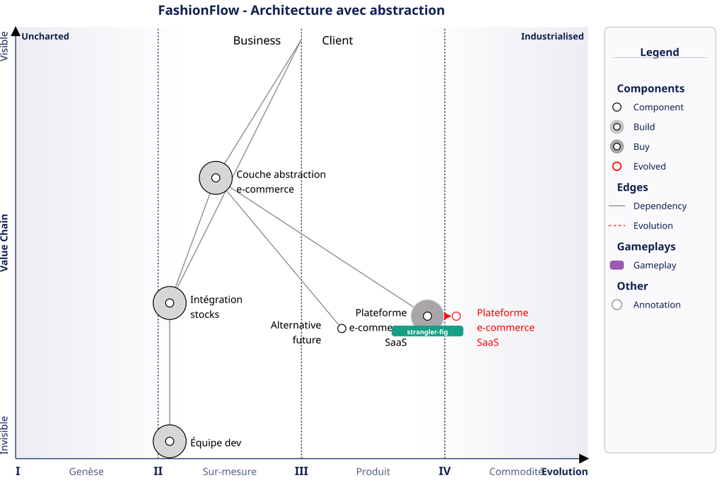

**Phase 2 : Migration progressive *Strangler Fig* (4 mois)** Le site sur-mesure existant continue de fonctionner pendant que la plateforme SaaS prend progressivement le relais. Chaque fonctionnalité est migrée une par une, validée en production, avant de passer à la suivante : le catalogue produits au premier mois, le panier et le tunnel de commande au deuxième, le paiement au troisième, puis le décommissionnement de l’ancien site au quatrième mois.

**Phase 3 : Alignement EVT** L’équipe de deux développeurs (profils Villageois) est réallouée sur l’intégration stocks (le composant réellement différenciant). Un freelance Urbaniste est recruté temporairement pour gérer la migration et l’optimisation des coûts de la plateforme SaaS.

**Résultats après 8 mois :**

Sur le plan **économique**, les coûts sont passés de 240 k€/an à 95 k€/an. La plateforme SaaS coûte 40 k€/an (licence + apps). L’hébergement cloud a été réduit à 5 k€/an (données stocks uniquement). La gouvernance SI reste à 45 k€/an mais pourrait être la prochaine cible. L’équipe de développement, désormais concentrée sur l’intégration, ne représente plus que 5 k€/an de coût marginal (le reste du temps est consacré à l’innovation).

Sur le plan **stratégique**, la couche d’abstraction offre une assurance contre le risque lié à la plateforme SaaS. Si la plateforme devient trop coûteuse ou non conforme, FashionFlow peut migrer vers PrestaShop, WooCommerce ou une solution souveraine en réutilisant 80% du code d’intégration. L’incertitude est gérée par la préservation d’options, pas par la prédiction.

Sur le plan **organisationnel**, les développeurs, libérés de la maintenance du site, ont créé trois nouvelles fonctionnalités omnicanales en six mois : réservation en magasin depuis le site, scan produit en magasin pour avis en ligne, et programme de fidélité unifié. Le CA additionnel estimé est de 150 k€/an.

**Leçon pour l’architecte :** Le Strangler Fig seul ne suffit pas quand l’incertitude est forte. Combiner la migration progressive avec une couche d’abstraction préserve les options futures. Le coût de cette abstraction (2 mois de développement) est une assurance contre le verrouillage, un investissement stratégique, pas une perte de temps.

### La *due diligence* stratégique

Les fusions et acquisitions sont des moments où la valeur peut être créée ou détruite massivement. La *due diligence* traditionnelle se concentre sur les aspects financiers et juridiques. La *due diligence* technique regarde la qualité du code.

Mais qui évalue la **cohérence stratégique** des actifs technologiques ?

La carte de Wardley peut servir d’outil de diagnostic dans le contexte M&A :

**Cartographier la cible.** Demander à l’entreprise cible de dessiner la carte de son système (ou la dessiner soi-même lors des audits).

**Détecter les anomalies.** L’entreprise présente-t-elle comme un « actif innovant » (Genèse) ce qui est en réalité une réinvention de la roue (Custom) d’une commodité existante ? Avoir développé son propre CRM ou son propre framework web en 2025 est un signal d’alarme : c’est de la dette déguisée en innovation.

**Évaluer l’adéquation des compétences.** L’équipe est-elle composée de profils « Explorateurs » alors que le produit est en phase d’industrialisation ? Cela annonce des problèmes de rétention après le rachat (ces profils s’ennuieront dans une phase de maintenance).

**Visualiser les synergies.** La superposition de la carte de l’acquéreur et celle de la cible révèle objectivement les doublons (à éliminer) et les complémentarités (à exploiter). Si les deux entreprises ont développé des stacks Custom incompatibles pour répondre aux mêmes besoins commoditaires, le coût d’intégration sera astronomique.

## Aligner les talents : Le modèle EVT

Pour réussir ces manœuvres, l’organisation doit aligner ses talents sur les phases d’évolution. C’est l’objet du modèle **EVT** (Explorateurs, Villageois, Urbanistes).

Le modèle EVT (*Explorers, Villagers, Town Planners*) distingue trois types de profils selon leur affinité naturelle avec les différentes phases d’évolution.

**Les Explorateurs** (*Explorers*) excellent dans la phase de Genèse. Ils sont à l’aise avec l’échec, l’incertitude et l’ambiguïté. Ils explorent les territoires inconnus, testent des hypothèses, acceptent que la majorité de leurs expériences ne mènent nulle part. Leur succès se mesure en découvertes, pas en livrables.

**Les Villageois** (*Villagers*) prennent les prototypes des explorateurs et les transforment en produits fiables et rentables. Ils excellent dans la phase Produit. Ils construisent, stabilisent, documentent. Ils sont cruciaux pour la phase de *Leverage* dans le modèle ILC.

**Les Urbanistes** (*Town Planners*) excellent dans l’industrialisation et l’optimisation. Ils gèrent les migrations vers le cloud, les refontes pour l’échelle, la maintenance des plateformes commoditisées. Leur obsession est l’efficience, la résilience, le coût unitaire.

Ce modèle est dérivé du travail de Robert X. Cringely[^11], qui dans son ouvrage *Accidental Empires* (1993) décrivait les entreprises technologiques comme composées de Commandos, d’Infanterie et de Police. Simon Wardley a adapté cette métaphore militaire au contexte de l’évolution des composants vers 2005-2006.

### Découvrir votre profil EVT

Avant de positionner vos équipes, commencez par vous-même. Quelques questions suffisent à révéler vos préférences naturelles.

L’**Explorateur** s’ennuie dans la répétition et s’épanouit dans l’inconnu. Si l’échec vous nourrit plutôt qu’il ne vous décourage, si les spécifications détaillées vous frustrent, vous en êtes probablement un. Cherchez les projets en phase Genèse, négociez le droit à l’échec, et préparez-vous à passer le relais quand le composant mûrit.

Le **Villageois** transforme les idées brutes en produits fiables. Si la fierté d’aider concrètement les utilisateurs et l’équilibre entre innovation et stabilité sont vos moteurs, c’est votre profil. Positionnez-vous sur les composants en phase Produit : vous êtes la courroie de transmission entre Explorateurs et Urbanistes.

L’**Urbaniste** est obsédé par la performance, l’efficience et le coût unitaire. Si optimiser l’existant vous semble plus gratifiant que créer du nouveau, c’est votre terrain. Ciblez les composants en phase Commodité et évitez les projets exploratoires qui vous frustreront.

La plupart des gens se reconnaissent dans un profil dominant, parfois deux. Ceux qui naviguent entre deux phases sont des traducteurs précieux (à condition de ne pas se disperser). Le profil n’est pas un diagnostic figé : il évolue avec l’expérience et le contexte.

L’erreur fatale est le mauvais alignement. Confier une migration à des Explorateurs produit de la sur-ingénierie et de la frustration. Confier l’innovation à des Urbanistes produit de la bureaucratie et de la paralysie. La bonne manœuvre exige les bonnes troupes au bon endroit.

### Reconnaître les profils dans votre organisation

Comment identifier les Explorateurs, Villageois et Urbanistes dans vos équipes ? Voici quelques indices.

**L’Explorateur** pose des questions comme : « Et si on essayait autrement ? » Il s’ennuie rapidement dans la routine. Il a tendance à sur-ingénierer les solutions (non par incompétence, mais parce qu’il cherche constamment à repousser les limites). Il est frustré par les processus rigides et les demandes de spécifications détaillées. Son bureau (ou son écran) est souvent encombré de prototypes abandonnés.

**Le Villageois** demande : « Comment on peut rendre ça utilisable ? » Il excelle à transformer une idée brute en quelque chose de fonctionnel et documenté. Il a le sens du client et de l’utilisabilité. Il est frustré quand on lui demande de travailler sur des concepts trop flous ou sur des systèmes trop industrialisés où il n’y a plus rien à construire.

**L’Urbaniste** s’interroge : « Comment on peut faire tourner ça à l’échelle ? » Son obsession est la fiabilité, la performance, le coût unitaire. Il est à l’aise avec les processus répétitifs et les métriques. Il est frustré par le chaos des projets exploratoires et par les prototypes « qui marchent sur ma machine ».

**Exemple : Spotify relu à travers le prisme EVT**

Spotify n’a jamais formellement utilisé le vocabulaire de Wardley. L’entreprise a développé son propre modèle organisationnel (Squads, Tribes, Chapters, Guilds), publié en 2012 par Henrik Kniberg et Anders Ivarsson[^12]. Pourtant, une lecture rétrospective à travers le prisme EVT est éclairante.

Les Squads dédiées aux nouvelles fonctionnalités expérimentales (recommandations, playlists, podcasts) rassemblaient des profils proches de l’Explorateur. Les équipes responsables de la stabilisation et du passage à l’échelle fonctionnaient comme des Villageois et des Urbanistes. Quand Spotify a tenté de mélanger ces profils sous les mêmes indicateurs de performance, les frictions ont été immédiates. L’entreprise a dû apprendre, parfois douloureusement, à respecter les affinités naturelles de ses équipes.

Ce cas illustre une réalité plus large : même sans connaître le modèle EVT, les organisations performantes finissent par le redécouvrir sous d’autres noms. Les frictions apparaissent quand elles l’ignorent.

### Le transfert entre phases : Orchestrer les transitions

Le modèle EVT soulève une question délicate mais inévitable : que se passe-t-il quand un composant change de phase ? Faut-il changer l’équipe ?

La réponse est nuancée. Certains individus sont capables de « glisser » d’une phase à l’autre (des Explorateurs qui apprennent à stabiliser, des Villageois qui deviennent Urbanistes). Mais ces transitions naturelles sont rares et ne doivent jamais être forcées.

#### Le principe du transfert formel

La pratique recommandée est le **transfert formel** : les Explorateurs passent le relais aux Villageois lors de la transition Genèse → Produit, et les Villageois aux Urbanistes lors du passage Produit → Commodité. Cette transition doit être **ritualisée, documentée, et célébrée** (pas subie comme un échec ou vécue comme une dépossession).

#### Les résistances typiques et comment les gérer

Les transitions se heurtent à trois résistances récurrentes que tout architecte doit savoir reconnaître et adresser.

**L’Explorateur qui refuse de lâcher prise.** Vous l’entendrez dire : « Ce n’est pas encore prêt », « Personne ne comprendra le code aussi bien que moi », « Laissez-moi juste finir cette dernière fonctionnalité ». Derrière ces mots se cachent un attachement émotionnel au projet, la peur de perdre son statut de créateur, et souvent le manque d’un nouveau défi stimulant qui l’attende.

La solution commence avant la transition elle-même. Préparez le prochain territoire d’exploration pour cet Explorateur (un nouveau composant en Genèse qui a besoin de quelqu’un capable de naviguer dans l’incertitude). Valorisez publiquement son travail : « Grâce à toi, nous avons prouvé que c’était possible. Maintenant, nous avons besoin que tu explores le territoire suivant. » Proposez-lui un rôle de mentor technique temporaire pour faciliter le transfert (cela légitime son expertise tout en organisant la passation). Et fixez une date de transfert ferme mais respectueuse, généralement deux à quatre semaines.

**Le Villageois qui s’accroche au produit mature.** Les symptômes sonnent différemment : « Il faut encore améliorer X », « Les utilisateurs comptent sur nous », « L’optimisation peut attendre ». Le Villageois est fier du travail accompli. Il tire satisfaction des retours directs des utilisateurs. L’idée de passer à une phase d’optimisation pure, où les retours sont moins immédiats, l’inquiète.

Identifiez pour lui le prochain produit en phase de maturation qui a besoin d’être stabilisé. Recadrez le passage à la Commodité comme une validation de son travail : « Le produit est si bon qu’il peut maintenant être industrialisé, c’est la preuve de ta réussite, pas un échec. » Proposez-lui un rôle de « gardien de la qualité » durant la migration vers Commodité : il s’assure que les Urbanistes comprennent l’intention initiale et ne cassent pas ce qui a été construit.

**L’Urbaniste frustré par un projet exploratoire.** Celui-ci ne cache pas sa frustration : « On ne peut pas mesurer les progrès », « Il n’y a aucun processus », « C’est du n’importe quoi ». C’est le signe d’un mauvais alignement initial : cet Urbaniste n’aurait jamais dû être affecté à ce projet.

La correction doit être immédiate. Retirez l’Urbaniste du projet exploratoire et affectez-le à un composant en phase Commodité ou en migration vers celle-ci. Apprenez de l’erreur pour améliorer le processus d’allocation des talents. Un Urbaniste mal placé paralyse l’innovation. Un Explorateur mal placé détruit la stabilité. L’alignement EVT n’est pas négociable.

#### Reconnaître les transitions mal gérées

Les symptômes sont lisibles : turnover anormal des Explorateurs après l’industrialisation de leur projet, sur-ingénierie des composants en Commodité, paralysie des projets en Genèse sous le poids de processus trop lourds. La plainte récurrente (« je ne fais plus ce pourquoi j’ai été embauché ») est le signal le plus fiable d’un mauvais alignement.

Les transitions réussies sont ritualisées : une rétrospective collective (qu’avons-nous appris ? de quoi sommes-nous fiers ?), un transfert formel et public de la responsabilité, puis une à deux semaines de recouvrement où les deux équipes coexistent. Le message doit être clair : la transition est une promotion collective, pas une dépossession.

**Principe d’or :** Les Explorateurs explorent, les Villageois construisent, les Urbanistes optimisent. Chacun libère le suivant plutôt que de bloquer sa progression.

## Grille d’analyse : Choisir sa manœuvre

Synthèse des principales manœuvres :

| Catégorie | Manœuvre | Objectif | Contexte idéal | Risque principal |
| --- | --- | --- | --- | --- |
| **Écosystème** | ILC | Capturer l’innovation externe et industrialiser les succès | Position de plateforme avec accès aux données d’usage | Perte de confiance de l’écosystème (« prédateur ») |
| **Accélération** | Open Source | Commoditiser un concurrent pour détruire sa marge | Attaque d’un concurrent tirant sa rente d’un complément propriétaire | Perte de contrôle si la communauté diverge (*fork*) |
| **Défense** | Château et Douves | Protéger une rente et maximiser le profit court terme | Produit mature générant du cash flow important | Aveuglement face à la rupture ; les douves s’assèchent |
| **Perception** | PID | Ralentir l’adoption d’une technologie concurrente | Acteur historique menacé par une innovation disruptive | Retour de bâton sur la réputation |
| **Plateforme** | Marchés à deux facteurs | Devenir l’intermédiaire indispensable | Opportunité de connecter producteurs et consommateurs | Problème poule/œuf avant la masse critique |
| **Capture** | Embrace and Extend | S’approprier un standard ouvert pour le verrouiller | Standard ouvert en croissance sur lequel vous avez un avantage | Réaction de la communauté, poursuites antitrust |
| **Conquête** | Land Grab | Occuper un marché avant les concurrents | Nouveau marché avec forts effets de réseau | Épuisement des ressources avant le point de bascule |
| **Opération** | Strangler Fig | Réduire la dette technique et retrouver de l’agilité | Système legacy bloquant l’évolution | Sous-estimation des dépendances |
| **Analyse** | Due Diligence | Évaluer la valeur réelle et les risques d’une acquisition | Processus M&A | Biais de confirmation |
| **Alignement** | Modèle EVT | Positionner les bons profils sur les bonnes phases | Organisation multi-projets avec composants à phases variées | Résistance des équipes au transfert |

## Fil rouge : La startup SaaS et le Cloud souverain — Les actions stratégiques

Revenons une dernière fois à notre startup française de gestion de projet (chapitres 8 et 9). Au chapitre 8, nous avons cartographié son système. Au chapitre 9, nous avons vu comment la carte a révélé le changement de visibilité du cloud provoqué par les Cygnes Noirs réglementaires (NIS2, IA Act, SecNumCloud).

Maintenant, **que faire** ? Quelles manœuvres du répertoire stratégique la startup peut-elle exécuter ?

### Le dilemme stratégique

**Situation :** Juillet 2023. La startup réalise 2M€ de chiffre d’affaires annuel, croissance +80% par an. Elle vient de perdre deux grands comptes (500k€ de MRR, *Monthly Recurring Revenue*, potentiel) à cause de l’hébergement AWS. Un concurrent souverain (OVHcloud) gagne des parts de marché.

L’équipe identifie quatre options : ne rien faire et parier que la pression souverainiste retombe, migrer totalement vers OVH (six mois, 300 k€), créer une couche d’abstraction multi-cloud via *Strangler Fig*, ou acquérir un concurrent déjà certifié SecNumCloud.

### La décision : *Strangler Fig* + Acquisition stratégique

L’équipe utilise la carte pour simuler les scénarios et choisit de combiner deux manœuvres.

En Phase 1 (immédiat, trois mois), l’équipe applique le *Strangler Fig* : création d’une couche d’abstraction infrastructure via Terraform multi-cloud, migration des données européennes vers OVHcloud (certifié SecNumCloud) tandis que les données non-européennes restent sur AWS (plus économique). Coût : 80k€ et deux développeurs pendant trois mois. Le gain est immédiat : un argumentaire commercial crédible (« données françaises hébergées sur OVH, SecNumCloud »).

En Phase 2 (six mois), la startup identifie un concurrent français 100% souverain mais au produit moins mature. La *due diligence* avec la carte de Wardley révèle beaucoup de dette technique (composants sur-mesure là où ils devraient être en Commodité), mais une certification SecNumCloud déjà obtenue (valeur stratégique considérable) et une équipe technique de cinq Urbanistes (bons pour maintenir, pas pour innover). Acquisition pour 800k€, dont 400k€ valorisés pour la certification (un an d’économie).

En Phase 3 (six à douze mois), l’intégration suit le modèle EVT : les Explorateurs de la startup créent de nouvelles fonctionnalités pendant que les Urbanistes de l’entreprise acquise migrent la base de code vers la plateforme consolidée, fusionnant les deux produits sur une architecture unifiée multi-cloud.

### Résultats après 18 mois

Dix-huit mois après le début de la transformation, les résultats sont mesurables sur tous les fronts.

Sur le plan **commercial**, la startup a récupéré les deux grands comptes perdus initialement (500k€ de MRR) et en a gagné cinq nouveaux grâce à l’argument souveraineté. La croissance s’est accélérée de trente-cinq points de pourcentage supplémentaires, directement attribuables à ce repositionnement stratégique.

L’architecture **technique** a évolué vers un modèle multi-cloud résilient (AWS pour les données non-européennes, OVH pour le marché européen). La certification SecNumCloud, obtenue via l’acquisition, a fait gagner douze mois sur le calendrier initial. Le coût cloud a été optimisé : les données européennes sur OVH coûtent trente pour cent de moins qu’AWS Europe.

Sur le plan **organisationnel**, l’équipe est passée de douze à dix-neuf personnes grâce à l’intégration de l’entreprise acquise. Les profils EVT se sont équilibrés naturellement : quatre Explorateurs travaillent sur les nouvelles fonctionnalités, huit Villageois stabilisent le produit, sept Urbanistes gèrent les opérations et les migrations. Le turnover est resté à zéro sur toute la période : les transitions EVT ont été bien gérées.

Le bilan **financier** justifie l’investissement. Pour un total de 1,2 millions d’euros (migration, acquisition, intégration), le retour sur investissement a été atteint en dix-huit mois grâce aux gains commerciaux et aux économies cloud. La valorisation de la startup a été multipliée par deux virgule cinq : l’argument souveraineté est devenu un moat temporaire qui protège la position concurrentielle.

### Leçons apprises

La carte a permis de simuler les options. Sans cartographie, l’équipe aurait probablement choisi la migration totale OVH (réaction émotionnelle à la perte de marchés). La carte a révélé qu’une approche *Strangler Fig* combinée à une acquisition était plus rapide et moins risquée.

Les Cygnes Noirs créent des fenêtres d’opportunité. Le changement réglementaire (NIS2) a créé un marché de consolidation : racheter des concurrents souverains sous-valorisés est devenu une stratégie viable.

Le succès ne vient pas d’une seule manœuvre brillante, mais de leur enchaînement cohérent. La startup a combiné le *Strangler Fig* (opérationnel), la *due diligence* stratégique (M&A), l’alignement EVT (organisationnel) et l’abstraction cloud (architecture). La puissance réside dans la manière dont ces manœuvres se renforcent mutuellement.

Pourtant, la startup a failli échouer sur un point doctrinal : « Connaître vos utilisateurs ». L’équipe avait supposé que « tous les clients européens voulaient la souveraineté ». Faux. Seuls les grands comptes et les secteurs régulés (santé, finance, public) le valorisaient vraiment. Les PME s’en fichaient. L’équipe a dû segmenter son offre (version souveraine premium vs version AWS standard). **Une bonne manœuvre ne compense pas une doctrine défaillante.**

## L’éthique du joueur

Ce pouvoir impose une réflexion éthique.

### Les limites éthiques des manœuvres

Certaines manœuvres décrites dans ce chapitre posent des questions éthiques sérieuses. Prenez le PID (Peur, Incertitude, Doute). La manœuvre consiste à disséminer des informations vraies ou vagues pour ralentir l’adoption d’une technologie concurrente. C’est de la manipulation pure. Si vous êtes découvert, votre réputation est détruite. Je décris cette manœuvre dans ce livre pour que vous sachiez la reconnaître quand elle est utilisée contre vous, pas pour que vous la pratiquiez.

Autre exemple : Embrace & Extend. Vous adoptez un standard ouvert, vous le soutenez publiquement, puis vous ajoutez progressivement des extensions propriétaires qui verrouillent vos utilisateurs. Microsoft a pratiqué cette stratégie avec brio dans les années 1990 contre Netscape. Le résultat ? Un procès antitrust. Aujourd’hui, avec le Digital Markets Act européen, ce type de manœuvre expose à des sanctions réglementaires massives. C’est légal jusqu’à ce que ça ne le soit plus. Et moralement, c’est discutable : vous trahissez la confiance de la communauté open source qui a construit le standard.

Même le modèle ILC, présenté comme vertueux, peut devenir prédateur. Si vous commoditisez les innovations de votre écosystème trop rapidement, vous étouffez l’innovation externe. Les startups qui vous alimentent en idées cessent de capturer de la valeur, donc elles cessent d’innover. Vous tuez la poule aux œufs d’or. L’équilibre est délicat : il faut laisser les innovateurs capturer suffisamment de valeur avant de commoditiser.

Avant d’exécuter une manœuvre, posez-vous quatre questions. Pourriez-vous expliquer publiquement cette manœuvre sans honte ? Accepteriez-vous qu’un concurrent fasse la même chose contre vous ? Y a-t-il un risque antitrust ou réglementaire (l’Union Européenne est très stricte) ? Cette manœuvre détruit-elle la confiance de l’écosystème à long terme ? Si une seule réponse vous dérange, repensez votre stratégie.

### Doctrine avant manœuvre

Manipuler les marchés, cultiver la peur chez les clients de vos concurrents, commoditiser des écosystèmes entiers — ces actions ont des conséquences qui dépassent votre bilan trimestriel. Des emplois sont créés ou détruits. Des entreprises naissent ou meurent. L’innovation est stimulée ou étouffée.

L’architecte du mouvement n’est pas un technicien amoral de la stratégie. Il est un acteur économique dont les décisions façonnent le paysage. Cette responsabilité ne doit jamais être oubliée.

De plus, rappelons une vérité fondamentale : **une bonne manœuvre ne peut sauver une organisation dont la doctrine est défaillante**. Si l’entreprise ne sait pas communiquer, ne respecte pas ses utilisateurs, fonctionne en silos et reconstruit des commodités, les manœuvres les plus brillantes échoueront. Le retour à la doctrine est un prérequis permanent.

La maîtrise des mouvements isolés n’est que la première étape. La véritable puissance stratégique émerge quand ces mouvements s’enchaînent en un système auto-renforçant : le **Flywheel stratégique**.

**EXERCICE : Diagnostiquer vos manœuvres actuelles**

Prenez la carte de votre système que vous avez construite au chapitre 8.

1. **Identifiez vos composants plateforme.** Y a-t-il des briques qui pourraient servir de fondation à un écosystème externe ?
2. **Repérez les compléments.** Quels composants sont des compléments à votre offre principale ? Pourriez-vous les commoditiser pour réduire les coûts de vos clients ?
3. **Évaluez vos douves.** Quelles barrières protègent vos produits différenciants ? Sont-elles durables ou sont-elles en train de s’assécher ?
4. **Analysez l’alignement EVT.** Pour chaque composant, le profil de l’équipe responsable correspond-il à la phase du composant ?
5. **Posez-vous la question éthique.** Les manœuvres que vous envisagez sont-elles compatibles avec vos valeurs et celles de votre organisation ?
[^1]: Simon Wardley, *Wardley Maps*, disponible en ligne sur medium.com/@swardley. Les manœuvres stratégiques (*gameplays*) sont détaillées dans les chapitres 11 à 13 de la série originale.
[^2]: Ce chiffre est une heuristique reconnue en R&D et capital-risque. Stevens et Burley (« 3,000 Raw Ideas = 1 Commercial Success! », *Research-Technology Management*, 1997) estiment qu’il faut en moyenne 3 000 idées brutes au stade de la genèse pour aboutir à un seul véritable succès commercial.
[^3]: Cette mécanique correspond au modèle ILC théorisé par Simon Wardley (*Wardley Maps*, chapitre 7). Pour DynamoDB : Werner Vogels *et al.*, « Dynamo: Amazon’s Highly Available Key-value Store », SOSP 2007.
[^4]: Rapports annuels Carrefour 2018-2023, disponibles sur carrefour.com. Plans stratégiques « Carrefour 2022 » (23 janvier 2018) et « Carrefour 2026 » (8 novembre 2022). Voir aussi les rapports LSA Commerce (lsa-conso.fr) et les communiqués de presse Carrefour (carrefour.com/fr/actualites).
[^5]: Ce mécanisme a été formalisé par Joel Spolsky dans son essai « Strategy Letter V: The Economics of Open Source », publié en 2002 sur joelonsoftware.com. Spolsky y montre que toute entreprise intelligente a intérêt à commoditiser les produits complémentaires aux siens pour augmenter la demande de ses propres produits.
[^6]: L’acquisition d’Android en 2005 puis son lancement en open source en 2007 via l’*Open Handset Alliance* est un cas d’école de la stratégie de « commoditisation du complément » théorisée par Joel Spolsky. En détruisant la barrière à l’entrée des OS mobiles, Google s’est assuré de maximiser le volume d’utilisateurs accédant à ses services.
[^7]: Warren Buffett utilise le concept d’« *Economic Moat* » (les douves économiques) dès sa lettre aux actionnaires de 1986, puis le développe en 2007. Voir aussi Pat Dorsey, *The Little Book That Builds Wealth*, Wiley, 2008, pour une formalisation complète du concept.
[^8]: L’effondrement de ces rentes de situation illustre la théorie de la disruption formulée par Clayton Christensen (*The Innovator’s Dilemma*, Harvard Business School Press, 1997). Nortel, incapable de s’adapter à la commoditisation du routage par le protocole IP ouvert, a fait faillite en 2009.
[^9]: La stratégie « *Embrace, extend, and extinguish* » a été formellement identifiée et exposée lors du procès antitrust *United States v. Microsoft Corp.* (jugement de 2001). Elle figurait dans des mémos internes de Microsoft (notamment de Paul Maritz, 1995) décrivant la stratégie pour évincer Netscape Navigator et Java.
[^10]: Cas fictif inspiré des pratiques de transformation digitale industrielle dans le secteur du pneumatique, notamment les communications publiques de Michelin (partenariat Rockwell Automation, 2023 ; plateforme Siemens MindSphere) et les retours d’expérience sur les migrations MES. Les métriques de coût et de performance sont des projections réalistes fondées sur les normes du secteur manufacturier. Voir aussi Bonnet, D. & Duke, L., « Michelin: Digital Transformation and Culture — Where the Rubber Hits the Road », IMD, 2021.
[^11]: Robert X. Cringely, *Accidental Empires: How the Boys of Silicon Valley Make Their Millions, Battle Foreign Competition, and Still Can’t Get a Date*, Addison-Wesley, 1993. :::
[^12]: Henrik Kniberg et Anders Ivarsson, « Scaling Agile @ Spotify », 2012. Sur les limites pratiques de ce modèle, voir Jeremiah Lee, « Spotify’s Failed #SquadGoals », 2020.

v2.16.0-beta